Zum Hauptinhalt springen

# Datenvisualisierung

Die Grammatik der Grafik mit `{ggplot2}`

Autor:in

**EPFL Extension School**

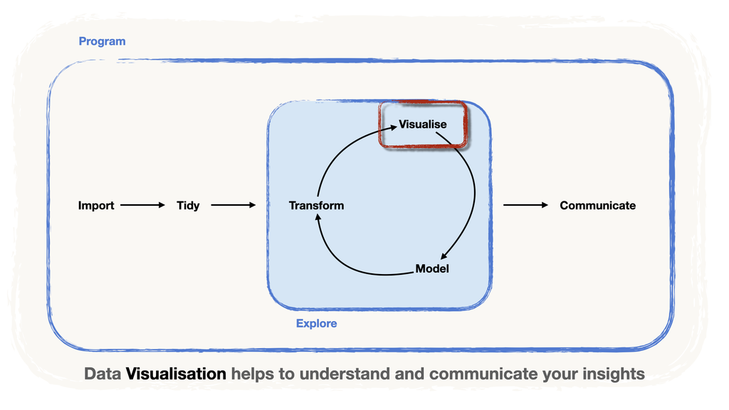

Wir lernen nun einen weiteren Schritt der Datenpipeline kennen: die Visualisierung.

- Die Datenvisualisierung ist ein wichtiger Teil der Erkundungsschleife,
- aber auch ein sehr wichtiges **Werkzeug, um Ergebnisse** klar und aussagekräftig **zu kommunizieren**.

Es gibt viele Ansätze, eine Grafik aus Daten zu erstellen. Heute konzentrieren wir uns auf den **Visualisierungsansatz**, der auf der **Grammatik der Datenvisualisierung** beruht und in R mit dem Paket `{ggplot2}` umgesetzt ist.

# 1 Eine Grammatik der Datenvisualisierung

Die Grammatik der Grafik (siehe [Wilkinson, 2005](https://link.springer.com/book/10.1007/0-387-28695-0)) ist ein Versuch, die **Erstellung quantitativer Grafiken** zu **systematisieren** und zu **erweitern**. Die Idee ist, **Regeln** aufzustellen, ähnlich der **Grammatik einer natürlichen Sprache**.

So wie eine natürliche Sprache syntaktische Bausteine wie **Nomen**, **Adjektive**, **Verben** und **Adverbien** verwendet, um **Aussagen** zu bilden, stützt sich die Grammatik der Grafik auf Bausteine, nämlich:

- **Daten**
- **Ästhetiken**
- **Geometrien**
- **Themes**

Sehen wir uns diese Bausteine im Detail an.

#### **Die Daten**

Der **Datensatz** mit den **Variablen, die wir darstellen wollen**. Nehmen wir zur Illustration einen Datensatz mit drei Spalten: **Variable 1**, **Variable 2** und **Group** (A, B oder C).

| Group | Variable 1 | Variable 2 |
| --- | --- | --- |
| A | 2.88 | 12.53 |
| A | 7.88 | 31.41 |
| A | 4.09 | 16.19 |
| A | 8.83 | 40.79 |
| A | 9.40 | 36.70 |
| A | 0.46 | 7.91 |

#### **Ästhetische Elemente und ästhetisches Mapping**

Die **Merkmale der Grafik**, d. h. die Elemente der Grafik, die von den Daten abhängen sollen. Zum Beispiel:

- die Achsen `x` oder `y`,
- die Farbe (`color`) oder die Füllfarbe (`fill`) der gezeichneten Flächen oder Linien,
- die Grösse (`size`) der Flächen.

Ein **ästhetisches Mapping** ist die Art, wie wir die **Variablen** unserer Daten mit der **Grafik verknüpfen**.

- In unserer Illustration haben wir zwei numerische Variablen und eine kategoriale Variable.
- Es ist sinnvoll, **die numerischen Variablen** den Achsen `x` und `y` **zuzuordnen** und die kategoriale Variable der Farbe (`color`).
- Das ästhetische Mapping lautet also `x = Variable 1`, `y = Variable 2` und `color = Group`.

#### **Geometrien**

Die **Art der Grafik**, die wir zeigen wollen.

- Hier möchten wir ein Streudiagramm, also wählen wir eine `point`-Geometrie mit `geom_point()`.
- Weitere Möglichkeiten sind Linien (`line`), Flächen (`area`), Säulen (`col`umn), Balken (`bar`)…
- Die Wahl hängt von der **Fragestellung** und der **Art der Variablen** ab.

#### **Themes**

Die ganze «Tinte», d. h. die rein kosmetischen Elemente der Grafik: die Titel, die Form der Achsen usw.

Mit diesen Elementen erstellen wir eine Grafik.

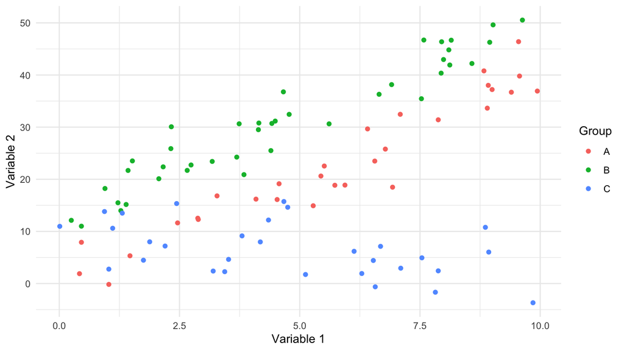

Aus dieser Grafik sehen wir:

1. Es gibt einen klaren linearen Zusammenhang zwischen Variable 1 und Variable 2.
2. Dieser Zusammenhang ist jedoch je nach Gruppe verschieden.

Sehen wir uns nun an, wie man in R mit `{ggplot2}` Grafiken nach der Grammatik der Grafik erstellt.

# 2 Die Syntax von `{ggplot2}`

Das Paket, das im `{tidyverse}` den Ansatz der Grammatik der Grafik umsetzt, ist `{ggplot2}`.

**Hinweis**

Es steckt sogar im Namen! Das «gg» steht für… **g**rammar of **g**raphics.

Für die Illustrationen verwenden wir die Daten der Grand-Slam-Einzelspiele der Frauen von 1968 bis 2021, gespeichert in `wta_grand_slam_data.csv`.

```r
library(readr)
library(dplyr)

wta <-
  "../data/wta_grand_slam_data.csv" %>%
  read_csv()

finals <- wta %>%
  filter(round == "F")

head(finals)
```

| year | tourney_id | tourney_name | surface | tourney_level | tourney_date | match_num | winner_id | winner_name | winner_hand | winner_ht | winner_ioc | winner_age | loser_id | loser_name | loser_hand | loser_ht | loser_ioc | loser_age | score | best_of | round | minutes | w_ace | w_df | w_svpt | w_1st_in | w_1st_won | w_2nd_won | w_sv_gms | … |
| --- | --- | --- | --- | --- | --- | --- | --- | --- | --- | --- | --- | --- | --- | --- | --- | --- | --- | --- | --- | --- | --- | --- | --- | --- | --- | --- | --- | --- | --- | --- |
| 1968 | 1968-W-SL-AUS-01A-1968 | Australian Championships | Grass | G | 19680119 | 61 | 200190 | Billie Jean King | R | NA | USA | 24.15880 | 200144 | Margaret Court | R | NA | AUS | 25.51129 | 6-1 6-2 | 3 | F | NA | NA | NA | NA | NA | NA | NA | NA | … |
| 1968 | 1968-W-SL-FRA-01A-1968 | Roland Garros | Clay | G | 19680527 | 95 | 200829 | Nancy Richey | R | 160 | USA | 25.76044 | 200193 | Ann Jones | L | NA | GBR | 29.63723 | 5-7 6-4 6-1 | 3 | F | NA | NA | NA | NA | NA | NA | NA | NA | … |
| 1968 | 1968-W-SL-GBR-01A-1968 | Wimbledon | Grass | G | 19680624 | 95 | 200190 | Billie Jean King | R | NA | USA | 24.58864 | 200160 | Judy Dalton | U | NA | AUS | 30.53251 | 9-7 7-5 | 3 | F | NA | NA | NA | NA | NA | NA | NA | NA | … |
| 1968 | 1968-W-SL-USA-01A-1968 | US Open | Grass | G | 19680829 | 63 | 200237 | Virginia Wade | R | NA | GBR | 23.13758 | 200190 | Billie Jean King | R | NA | USA | 24.76934 | 6-4 6-2 | 3 | F | NA | NA | NA | NA | NA | NA | NA | NA | … |
| 1969 | 1969-W-SL-AUS-01A-1969 | Australian Open | Grass | G | 19690120 | 31 | 200144 | Margaret Court | R | NA | AUS | 26.51608 | 200190 | Billie Jean King | R | NA | USA | 25.16359 | 6-4 6-1 | 3 | F | NA | NA | NA | NA | NA | NA | NA | NA | … |
| 1969 | 1969-W-SL-FRA-01A-1969 | Roland Garros | Clay | G | 19690526 | 63 | 200144 | Margaret Court | R | NA | AUS | 26.86105 | 200193 | Ann Jones | L | NA | GBR | 30.63381 | 6-1 4-6 6-3 | 3 | F | NA | NA | NA | NA | NA | NA | NA | NA | … |

**Wichtig**

Wichtig ist zu verstehen, dass `{ggplot2}` mit **Informationsschichten** (*layers*) arbeitet.

- Zuerst erstellen wir einen **Basisplot**, bestehend aus
  - den **Daten** und…
  - dem **ästhetischen Mapping**…
- …dem wir dann die **Geometrien** hinzufügen…
- …und danach alle kosmetischen Elemente und weiteren Schichten.

# 3 Streudiagramme mit `geom_point()`

> *Gibt es einen **Trend beim Alter** der Turniersiegerinnen über die **Jahre**?*

Wir laden das Paket wie gewohnt mit `library()`. Um dann die Basisschicht zu erstellen, rufen wir die Funktion `ggplot()` auf:

- Wir legen die Daten mit `data = finals` fest.
- Ausserdem bilden wir die `x`-Achse auf `year` und die `y`-Achse auf `winner_age` ab.

**Wichtig**

Das **ästhetische Mapping** definieren wir mit der Funktion `aes(...)`.

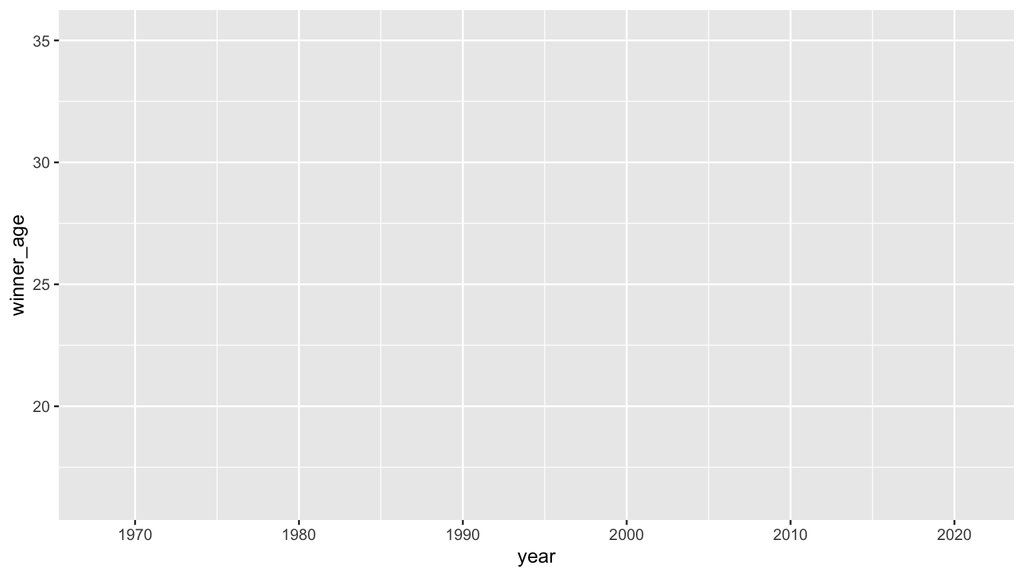

```r
# ggplot2 laden
library(ggplot2)

# einen Basisplot erstellen
ggplot(data = finals, # die Daten
       mapping = aes(
        x = year, # die x-Achse auf year abbilden
        y = winner_age) # die y-Achse auf winner_age abbilden
       )
```

> Noch nichts! Die Geometrie fehlt! Aber welche Geometrie sollen wir hinzufügen?
- Beginnen wir mit **Punkten**: Wir wollen einen Punkt pro Beobachtung.
- Wir legen die **Geometrie** mit `geom_point()` fest…
  - …die wir mit dem Zeichen `+` **zu unserer Basisschicht hinzufügen** müssen.

**Warnung**

In `{ggplot2}` fügen wir Schichten mit `+` statt mit `%>%` hinzu!

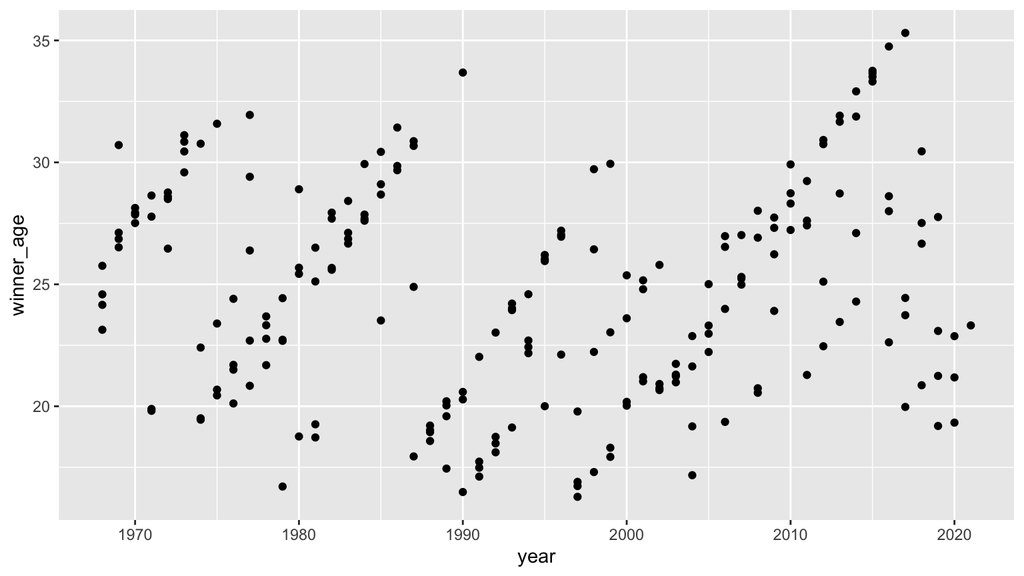

```r
library(ggplot2)

ggplot(data = finals, # die Daten
       mapping = aes(
        x = year, # die x-Achse auf year abbilden
        y = winner_age) # die y-Achse auf winner_age abbilden
       ) +
  geom_point() # unsere gewählte Geometrie: Punkte
```

> Leider nicht sehr aufschlussreich.
- Es gibt **keinen einheitlichen Trend** beim Alter der WTA-Siegerinnen über die Zeit.
- Aber wir sehen **Gruppen** (*clusters*), d. h. Bereiche, in denen die Punkte auf einer Linie liegen.

> Könnte es Trends innerhalb einer Gruppe geben?
- Um das zu prüfen, könnten wir eine kategoriale Variable auf die Ästhetik `color` abbilden.
- Versuchen wir es mit `surface`, d. h. ob das Spiel auf Sand (Clay), Rasen (Grass) oder Hartplatz (Hard) gespielt wird.

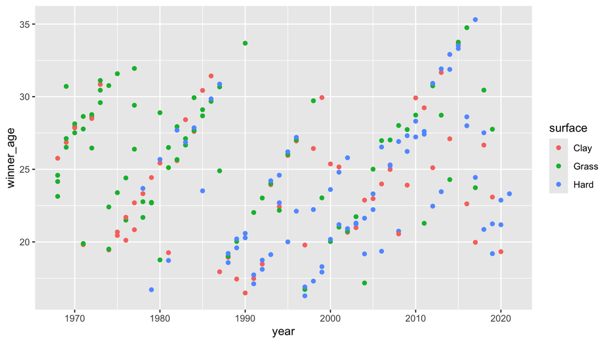

```r
library(ggplot2)

ggplot(data = finals,
       mapping = aes(
        x = year,
        y = winner_age,
        color = surface)
       ) + # surface auf color abbilden
  geom_point()
```

> Die Punkte haben jetzt **Farben**… aber immer noch keinen einheitlichen Trend.

> Sollen wir es mit einer anderen Variable versuchen? Vielleicht entstehen diese Gruppen, weil **dieselbe Spielerin über viele Jahre gewinnt** und dabei **älter wird**.
- Prüfen wir diese Vermutung, indem wir `winner_name` auf die Ästhetik `color` abbilden…

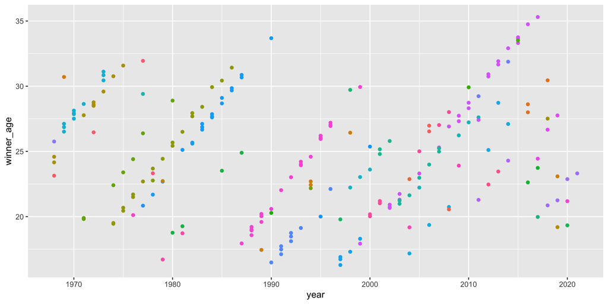

```r
library(ggplot2)

ggplot(data = finals,
       mapping = aes(
        x = year,
        y = winner_age,
        color = winner_name) # winner_name auf color abbilden
        ) +
  geom_point() +
  theme(legend.position = "none") # 54 Spielerinnen: zu viele für eine lesbare Legende
```

> Voilà! Die meisten **Punkte derselben Farbe liegen auf einer Linie**: Das erklärt die Gruppen.

**Hinweis**

Eine dritte Variable auf eine Ästhetik wie die Farbe abzubilden, hilft oft, Trends innerhalb von **Gruppen** zu entdecken.

**TippBeachten Sie die Chunk-Option!**

Wir haben eine Grösse der Grafik in den Chunk-Optionen festgelegt (`fig.width=10, fig.height= 5`), weil wir **die Grafik vergrössern** wollen.

Wir haben auch **die Legende ausgeblendet**: Bei 54 verschiedenen Spielerinnen könnte niemand 54 Farben ihren Namen zuordnen. Hier müssen wir nur sehen, dass Punkte derselben Farbe auf einer Linie liegen.

**HinweisDie Grafik nach Belag war nicht nutzlos**

Sie sehen, dass es **vor 1977** weniger blaue Punkte gibt: Die Turniere wurden nur auf *Rasen* oder *Sand* gespielt, *Hartplätze* kamen erst nach diesem Jahr dazu.

# 4 Boxplots mit `geom_boxplot()`

> *Unterscheidet sich die Verteilung des Alters der Turniersiegerinnen zwischen den verschiedenen Belägen?*

Wir können nun **eine andere Frage** stellen und versuchen, sie mit einer **anderen Geometrie** zu beantworten. Boxplots sind eine gute Wahl, da sie **Verteilungen** gut **zusammenfassen**.

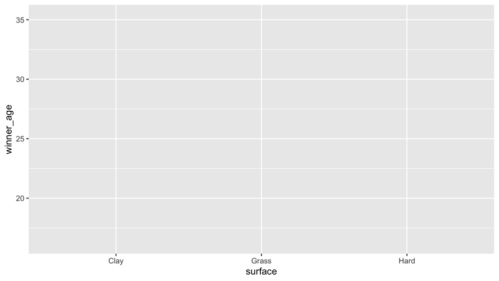

```r
ggplot(data = finals,
       mapping = aes(x = surface, # wir ändern das Mapping der x-Achse
                     y = winner_age))
```

Für die Boxplot-Geometrie fügen wir `geom_boxplot()` hinzu:

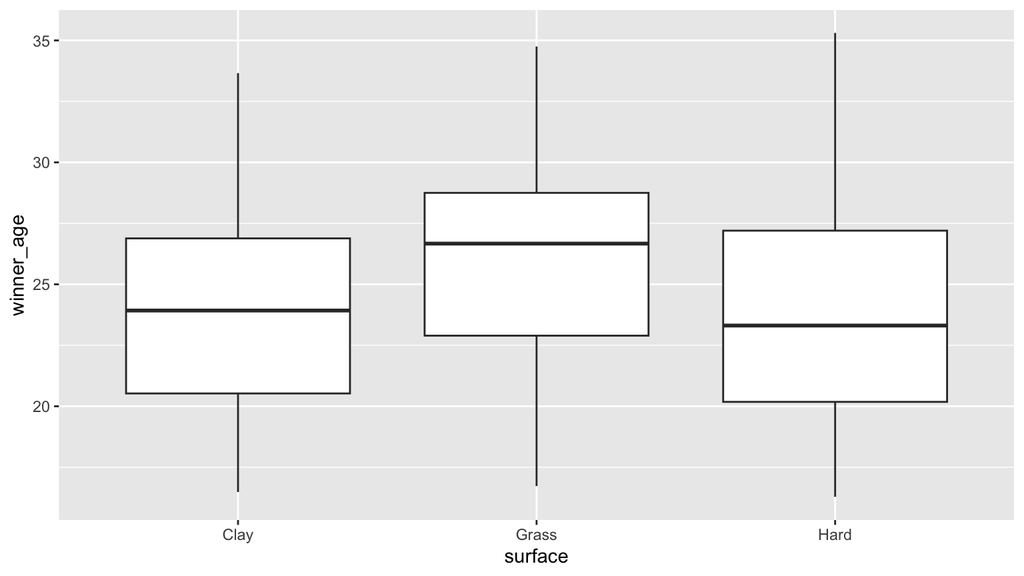

```r
ggplot(data = finals,
       mapping = aes(x = surface,
                     y = winner_age)) +
  geom_boxplot() # die Geometrie für den Boxplot hinzufügen
```

**HinweisWoher kommen die Boxen?**

Die Kennzahlen für die Boxplots (d. h. der Median, das obere und das untere Quartil) werden beim Zeichnen der Grafik aus den «rohen» Daten berechnet.

> Voilà! Offenbar begünstigt der **Rasen** die **älteren Spielerinnen**, während die **jüngeren Spielerinnen** auf **Hartplätzen gewinnen**.

> (Wir können **vermuten**, dass der Ball auf **Rasen etwas langsamer** und auf **Hartplätzen schneller** ist, was die «physischeren», also jüngeren, Spielerinnen begünstigt!)

**WarnungExplorative Datenanalyse**

Wenn wir die Daten so darstellen, erhalten wir einen guten Hinweis darauf, ob es Unterschiede zwischen den Kategorien gibt. Solche Grafiken dienen also der **Erkundung** der Zusammenhänge zwischen Variablen.

Um diese Zusammenhänge zu **bestätigen**, braucht es jedoch **mehr Arbeit**.

- Zum Beispiel kann ein **statistischer Test** bestätigen, dass die beobachteten Unterschiede nicht zufällig sind.
- (Dabei sollten wir bedenken, dass die Beobachtungen nicht ganz unabhängig voneinander sind!)

# 5 Weitere Geometrien `geoms_*` hinzufügen

Wie bereits erwähnt, arbeitet `{ggplot2}` mit **Informationsschichten**. In unseren Beispielen haben wir den **Basisplot** gezeichnet und dann **eine einzige Geometrie** hinzugefügt (Punkte oder Boxplot).

Konzentrieren wir uns auf den Vergleich des Alters der Siegerinnen zwischen den Belägen. Was, wenn wir mehr Information zeigen möchten? Zum Beispiel:

> - Gibt es Unterschiede in der Anzahl Beobachtungen pro Kategorie?
> - Gibt es Extremwerte?

Legen wir *Punkte* **über den Boxplot**, indem wir die Geometrie `geom_point()` hinzufügen:

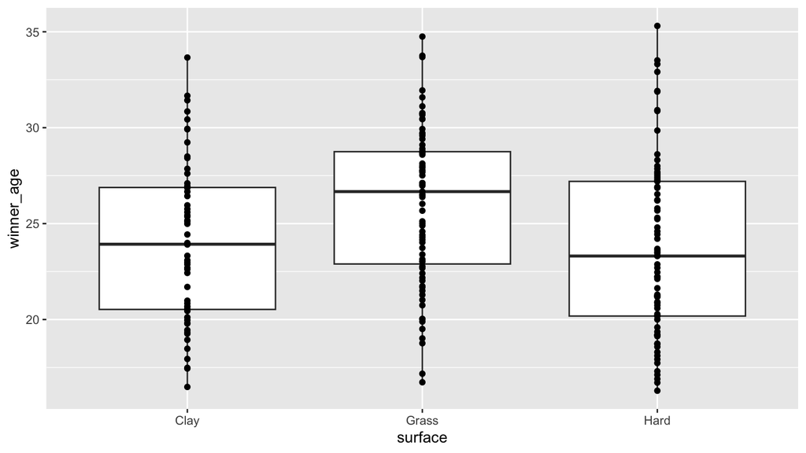

```r
ggplot(data = finals,
       mapping = aes(x = surface,
                     y = winner_age)) +
  geom_boxplot() +
  geom_point() # eine neue Geometrie für dieselben Mappings hinzufügen
```

**WarnungVorsicht vor Overplotting!**

Jetzt haben wir ein kleines Visualisierungsproblem: **Overplotting**!

- Overplotting entsteht, wenn **viele Punkte übereinander gezeichnet werden, sodass einzelne Punkte schwer zu erkennen sind.**
- Das passiert oft, wenn wir Punkte über kategoriale Variablen zeichnen.

Um die Falle des Overplottings zu vermeiden, «schütteln» wir die Punkte zufällig entlang der x-Achse. Dazu ändern wir die Geometrie zu `geom_jitter()`:

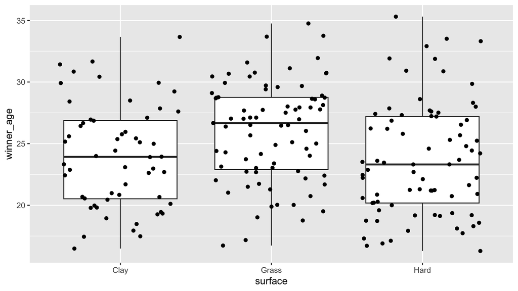

```r
ggplot(data = finals,
       mapping = aes(x = surface,
                     y = winner_age)) +
  geom_boxplot() +
  geom_jitter() # Jitter darüberlegen
```

Wir können den Jitter etwas anpassen, indem wir die Breite (`width`) der Streuung festlegen:

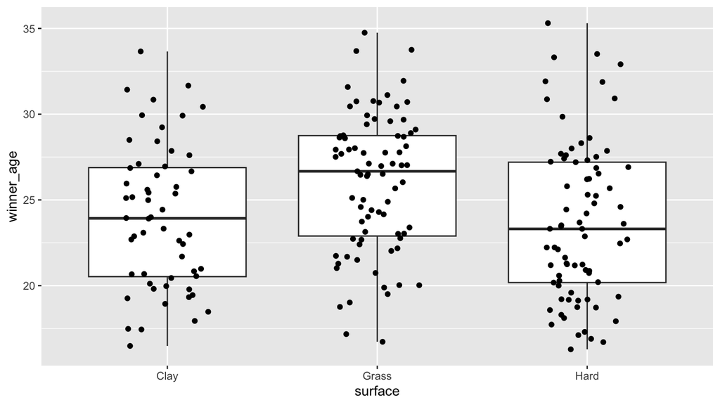

```r
ggplot(data = finals,
       mapping = aes(x = surface,
                     y = winner_age)) +
  geom_boxplot() +
  geom_jitter(width = 0.2) # die Punkte etwas weniger streuen
```

**HinweisJede Schicht hat Argumente**

Beachten Sie, dass wir das Argument `width` angepasst haben. Allgemein gilt: Jede Schicht ist eine Funktion, also hat sie Argumente!

# 6 Fallstudie: ein Balkendiagramm gestalten

Stellen wir eine andere Frage:

> *Wer hat die meisten Grand-Slam-Titel gewonnen*?

Erstellen wir zuerst den Datensatz, in dem wir die von jeder Spielerin gewonnenen Finals zählen, und sehen wir uns seine ersten Zeilen an.

**Hinweis**

Setzen wir unsere Kenntnisse der **Datenaufbereitung** ein!

```r
total_wins <- finals %>%
  group_by(winner_name) %>%
  summarise(total_wins = n(), .groups = "drop") %>%
  arrange(desc(total_wins))

slice_head(total_wins, n = 6)
```

| winner_name | total_wins |
| --- | --- |
| Serena Williams | 23 |
| Steffi Graf | 22 |
| Chris Evert | 18 |
| Martina Navratilova | 18 |
| Margaret Court | 11 |
| Billie Jean King | 9 |

Mit `geom_col()` können wir daraus eine Grafik erstellen:

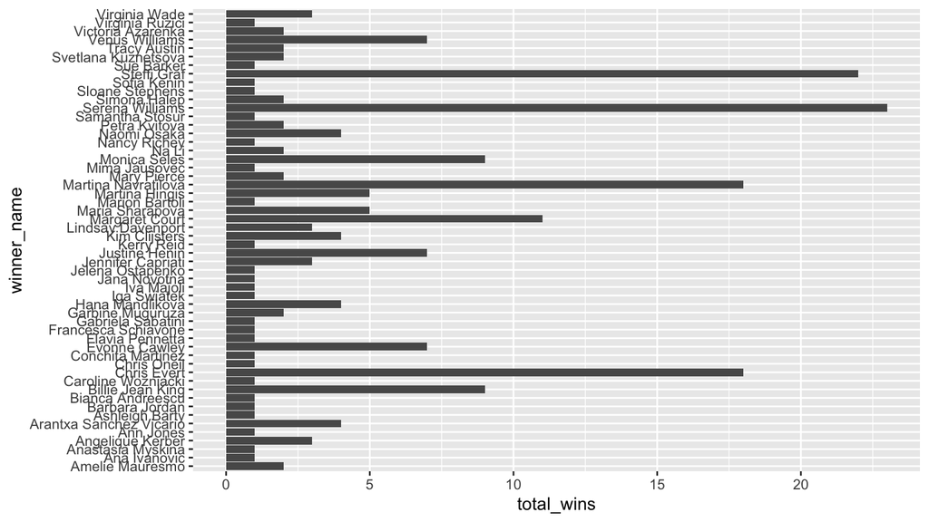

```r
ggplot(data = total_wins,
       mapping = aes(x = total_wins,
                     y = winner_name)) +
  geom_col()
```

Zeit für etwas mehr Schliff mit den Werkzeugen von `{ggplot2}`!

## 6.1 Die Balken ordnen

Im Moment sind die Balken in alphabetischer Reihenfolge von `winner_name` geordnet:

- Das liegt daran, dass `winner_name` noch vom Typ `character` ist,
- und `ggplot()` reagiert nicht auf unseren Aufruf von `arrange()`!

**Wichtig**

Um die Balken zu ordnen, müssen wir für die Variable `winner_name` **eine neue Reihenfolge festlegen**. Dazu wandeln wir sie in einen `factor` um: einen Variablentyp **mit einer Reihenfolge**. Im `{tidyverse}` verwenden wir dafür das Paket `{forcats}`.

Ordnen wir `winner_name` mit `forcats::fct_reorder()` nach `total_wins`:

```r
library(forcats)

total_wins <- total_wins %>%
  # winner_name nach total_wins ordnen
  mutate(winner_name = fct_reorder(winner_name, total_wins))
```

Mit `glimpse()` sehen Sie, dass `winner_name` jetzt als Faktor (`fct`) gespeichert ist!

```r
glimpse(total_wins)
```

```
Rows: 54
Columns: 2
$ winner_name <fct> Serena Williams, Steffi Graf, Chris Evert, Martina Navrati…
$ total_wins  <int> 23, 22, 18, 18, 11, 9, 9, 7, 7, 7, 5, 5, 4, 4, 4, 4, 3, 3,…
```

Zeichnen wir die Grafik noch einmal…

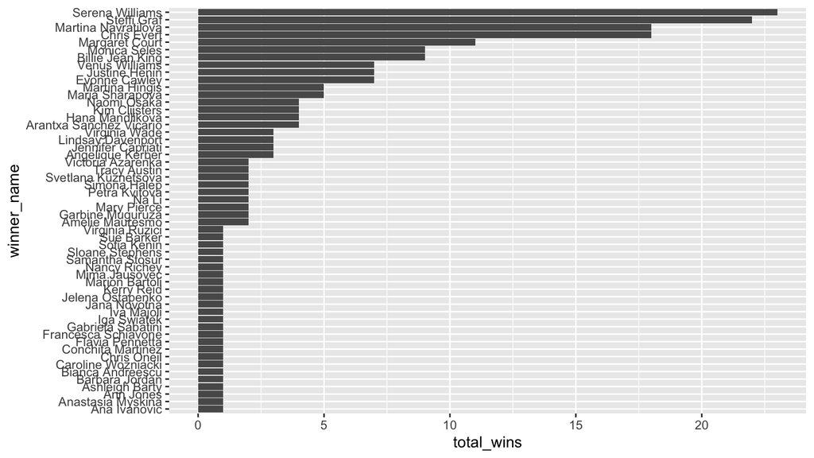

```r
ggplot(data = total_wins,
       mapping = aes(x = total_wins,
                     y = winner_name)) +
  geom_col()
```

> Die Grafik ist schon viel lesbarer! …aber wie können wir sie verbessern?

## 6.2 Unsere Botschaft fokussieren

Wir können uns zum Beispiel **auf die Top 20 konzentrieren**:

- Dafür verwenden wir `slice_max()`…
- …und übergeben das Ergebnis direkt an `ggplot()`,
- so bleibt das ursprüngliche Tibble unverändert.

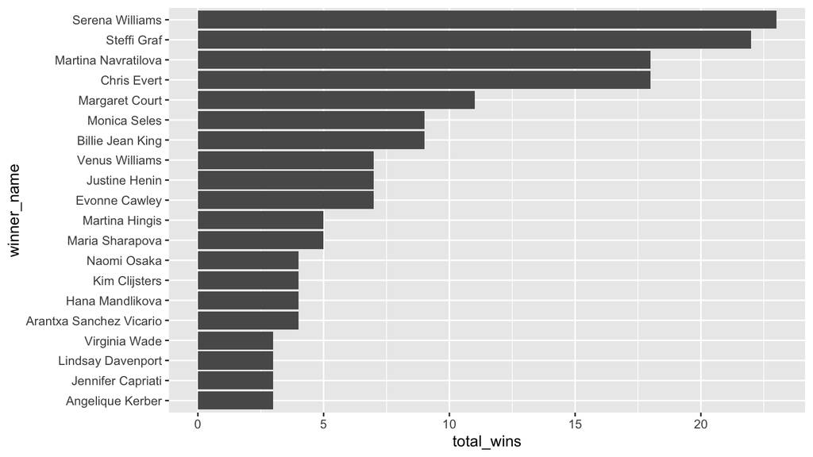

```r
total_wins %>%
  slice_max(order_by = total_wins, n = 20) %>%
  ggplot(mapping = aes(x = total_wins,
                       y = winner_name)) +
  geom_col()
```

> Viel besser, die Grafik spricht fast für sich. Aber kümmern wir uns um die Achsen.

## 6.3 Zeit für Kosmetik!

Zeit, einen Titel hinzuzufügen und die Achsennamen anzupassen. Dazu fügen wir unserer Grafik eine `labs()`-Schicht hinzu.

**Hinweis**

Die Schicht `labs()` gehört zu den Schichten, die sich um die *kosmetischen* Aspekte der Grafik kümmern.

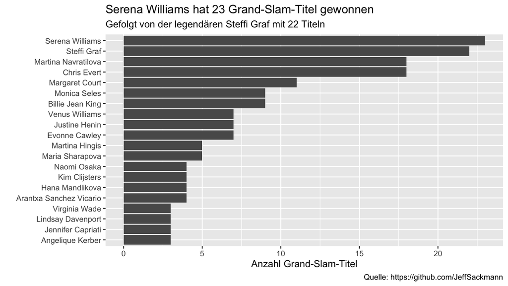

```r
total_wins %>%
  slice_max(order_by = total_wins, n = 20) %>%
  ggplot(mapping = aes(x = total_wins,
                       y = winner_name)) +
  geom_col() +
  # Beschriftungen hinzufügen
  labs(title = "Serena Williams hat 23 Grand-Slam-Titel gewonnen",
       subtitle =  "Gefolgt von der legendären Steffi Graf mit 22 Titeln",
       x = "Anzahl Grand-Slam-Titel",
       y = "",
       caption = "Quelle: https://github.com/JeffSackmann")
```

> Jetzt können wir der Grafik ein anderes Theme geben.

**Hinweis**

`{ggplot2}` bietet mehrere fertige Themes. Eine Liste finden Sie [hier](https://ggplot2.tidyverse.org/reference/ggtheme.html). Einige davon:

- `theme_minimal()`: ein guter Ausgangspunkt
- `theme_dark()`: wenn [Sie es dunkler wollen](https://youtu.be/v0nmHymgM7Y)
- `theme_bw()`: um alles in Schwarz-Weiss zu sehen
- `theme_classic()`

Die Vorschläge sehen Sie, wenn Sie `theme_` in die Konsole tippen.

Wählen wir `minimal`…

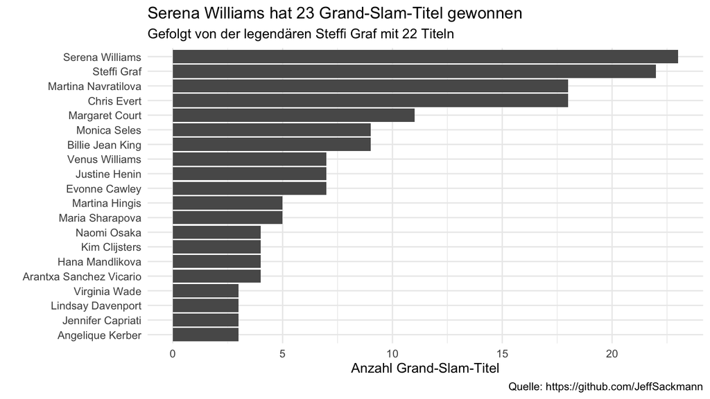

```r
total_wins %>%
  slice_max(order_by = total_wins, n = 20) %>%
  ggplot(mapping = aes(x = total_wins,
                       y = winner_name)) +
  geom_col() +
  labs(title = "Serena Williams hat 23 Grand-Slam-Titel gewonnen",
       subtitle =  "Gefolgt von der legendären Steffi Graf mit 22 Titeln",
       x = "Anzahl Grand-Slam-Titel",
       y = "",
       caption = "Quelle: https://github.com/JeffSackmann") +
  # ein Theme hinzufügen
  theme_minimal()
```

## 6.4 Wie wäre es mit etwas Farbe?

Geben wir unseren Balken Farbe. Wir können `fill = "lightblue"` verwenden…

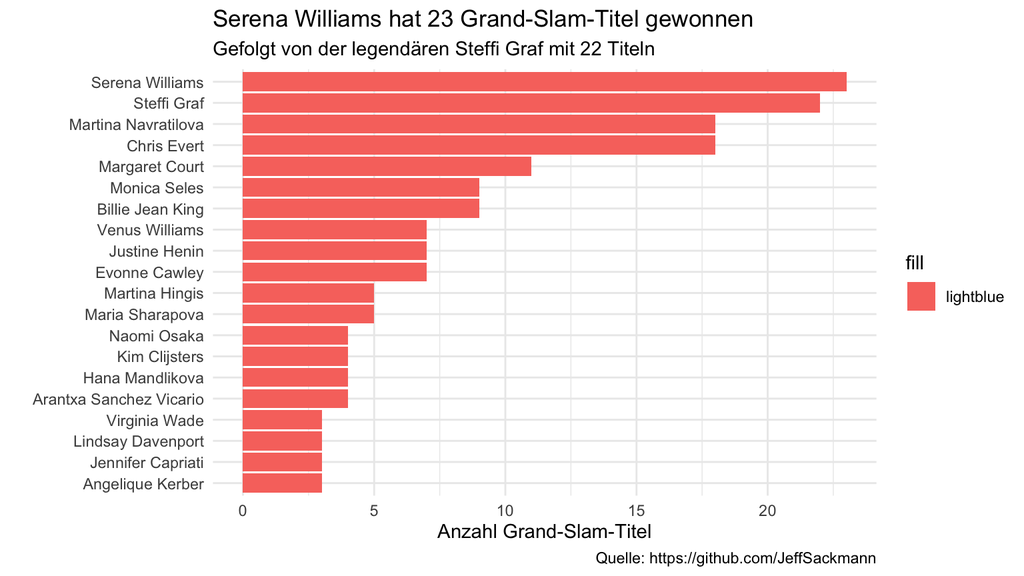

```r
total_wins %>%
  slice_max(order_by = total_wins, n = 20) %>%
  ggplot(mapping = aes(x = total_wins,
                       y = winner_name,
                       fill = "lightblue")) +
  geom_col() +
  labs(title = "Serena Williams hat 23 Grand-Slam-Titel gewonnen",
       subtitle =  "Gefolgt von der legendären Steffi Graf mit 22 Titeln",
       x = "Anzahl Grand-Slam-Titel",
       y = "",
       caption = "Quelle: https://github.com/JeffSackmann") +
  theme_minimal()
```

> Oh nein! Etwas stimmt nicht… Erraten Sie, was?

**WarnungWas ist hier los?**

- Wenn wir `fill = "lightblue"` in den Aufruf von `aes()` schreiben, **bilden wir eine Variable** mit dem **einzigen Wert** `"lightblue"` auf die Füllfarbe (`fill`) der Balken ab…
- …statt sie als **Parameter** festzulegen!
- `ggplot()` versteht nicht, dass `"lightblue"` eigentlich eine Farbe ist, die wir setzen wollen.
- Ein Mapping wäre sinnvoll, wenn die Farbe der Balken von der Anzahl `total_wins` abhängen soll.
- Das erzeugt eine kontinuierliche Farbskala für die Farbe der Balken.

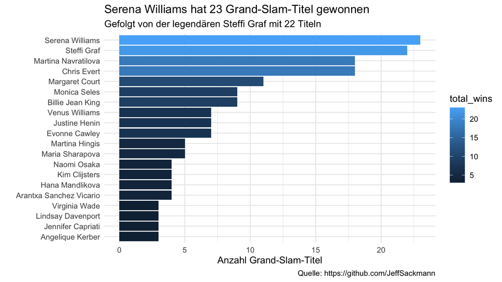

```r
total_wins %>%
  slice_max(order_by = total_wins, n = 20) %>%
  ggplot(mapping = aes(x = total_wins,
                       y = winner_name,
                       fill = total_wins)) +
  geom_col() +
  labs(title = "Serena Williams hat 23 Grand-Slam-Titel gewonnen",
       subtitle =  "Gefolgt von der legendären Steffi Graf mit 22 Titeln",
       x = "Anzahl Grand-Slam-Titel",
       y = "",
       caption = "Quelle: https://github.com/JeffSackmann") +
  theme_minimal()
```

Wenn wir allen Balken eine Farbe geben wollen, müssen wir das **ausserhalb von `aes()`** tun, d. h. **im `geom_*()`**:

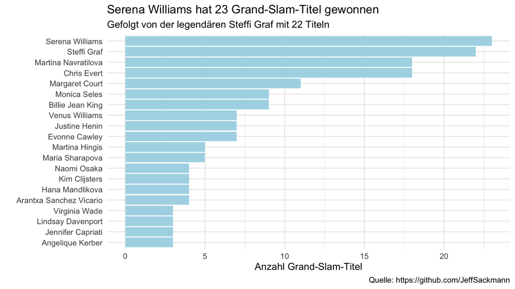

```r
total_wins %>%
  slice_max(order_by = total_wins, n = 20) %>%
  ggplot(mapping = aes(x = total_wins,
                       y = winner_name)) +
  geom_col(fill = "lightblue") + # eine Farbe für alle Balken festlegen
  labs(title = "Serena Williams hat 23 Grand-Slam-Titel gewonnen",
       subtitle =  "Gefolgt von der legendären Steffi Graf mit 22 Titeln",
       x = "Anzahl Grand-Slam-Titel",
       y = "",
       caption = "Quelle: https://github.com/JeffSackmann") +
  theme_minimal()
```

# 7 Fallstudie: mehr Variablen darstellen

Wir können uns fragen:

> *Hat Serena Williams auf allen Belägen mehr gewonnen als Steffi Graf?*

Wie können wir das visuell erkennen?

- Zuerst brauchen wir einen Datensatz, der **die gewonnenen Finals pro Spielerin** und **pro Belag zählt**…
- …dann versuchen wir, `surface` auf `fill` abzubilden…
- …aber Achtung! Wir müssen **die Daten zuerst neu ordnen**, damit die Balken wieder geordnet sind.

**HinweisWeitere praktische `{forcats}`-Tricks**

- `fct_infreq()` ordnet Faktoren nach Häufigkeit: Auf `winner_name` angewendet, ordnet es die Spielerinnen, ohne dass wir zählen müssen!
- `fct_rev()` kehrt die Reihenfolge um, damit sie **absteigend** ist.

```r
total_wins_surface <- finals %>%
  mutate(winner_name = fct_rev(fct_infreq(winner_name))) %>% # die Namen der Siegerinnen neu ordnen
  group_by(winner_name, surface) %>%
  summarise(total_wins = n(), .groups = "drop") %>%
  arrange(surface, desc(total_wins))
```

Um unsere Botschaft zu fokussieren, können wir unsere Top 20 verwenden. Ziehen wir die Namen der Top 20 aus dem Datensatz `total_wins`… und speichern sie im Vektor (`vector`) `top20`:

```r
top20 <- total_wins %>%
  slice_max(order_by = total_wins, n = 20) %>%
  pull(winner_name)

top20
```

```
 [1] Serena Williams         Steffi Graf             Chris Evert
 [4] Martina Navratilova     Margaret Court          Billie Jean King
 [7] Monica Seles            Evonne Cawley           Justine Henin
[10] Venus Williams          Maria Sharapova         Martina Hingis
[13] Arantxa Sanchez Vicario Hana Mandlikova         Kim Clijsters
[16] Naomi Osaka             Angelique Kerber        Jennifer Capriati
[19] Lindsay Davenport       Virginia Wade
54 Levels: Ana Ivanovic Anastasia Myskina Ann Jones ... Serena Williams
```

Jetzt können wir die Grafik zeichnen.

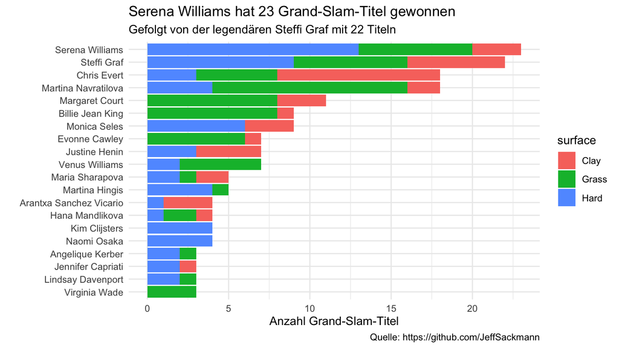

```r
total_wins_surface %>%
  filter(winner_name %in% top20) %>%
  ggplot(mapping = aes(x = total_wins,
                         y = winner_name,
                         fill = surface)) +
  geom_col() +
  labs(
    title = "Serena Williams hat 23 Grand-Slam-Titel gewonnen",
    subtitle =  "Gefolgt von der legendären Steffi Graf mit 22 Titeln",
    x = "Anzahl Grand-Slam-Titel",
    y = "",
    caption = "Quelle: https://github.com/JeffSackmann"
  ) +
  theme_minimal()
```

> Wir sehen:
> - Steffi Graf hat auf Sand mehr gewonnen als Serena Williams,
> - und Serena hat auf Hartplatz mehr gewonnen.

> Aber auf Rasen ist der Vergleich sehr schwierig! Da gibt es klar Verbesserungspotenzial.

# 8 Mehrere Mini-Grafiken erstellen

Um die Spielerinnen auf den verschiedenen Belägen zu vergleichen, können wir eine andere Strategie wählen: eine **Mini-Grafik pro Belag**. Dazu fügen wir eine `facet_wrap()`-Schicht hinzu.

**Hinweis**

Die Mini-Grafiken heissen in *`R`* *«Facetten»* (*facets*).

**Wichtig**

Die Syntax ist etwas anders: Den Namen der Variable, die die Grafik in Facetten aufteilt, müssen wir in die Funktion `vars()` einschliessen.

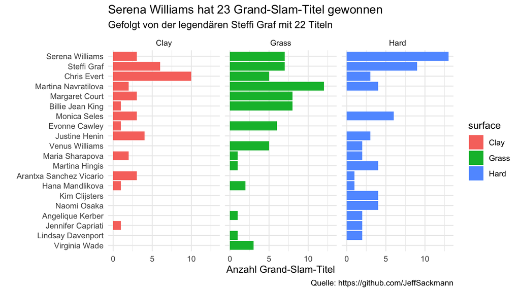

```r
total_wins_surface %>%
  filter(winner_name %in% top20) %>%
  ggplot(mapping = aes(x = total_wins,
                         y = winner_name,
                         fill = surface)) +
  geom_col() +
  labs(
    title = "Serena Williams hat 23 Grand-Slam-Titel gewonnen",
    subtitle =  "Gefolgt von der legendären Steffi Graf mit 22 Titeln",
    x = "Anzahl Grand-Slam-Titel",
    y = "",
    caption = "Quelle: https://github.com/JeffSackmann"
  ) +
  theme_minimal() +
  facet_wrap(vars(surface)) # surface als Facetten-Variable verwenden
```

Jetzt können wir die Legende ausblenden, da sie überflüssig ist.

**HinweisAuch die Farben sind überflüssig**

Auch die Farben sind hier eher überflüssig, aber wir behalten sie aus persönlichem Geschmack; Sie dürfen sie gerne entfernen.

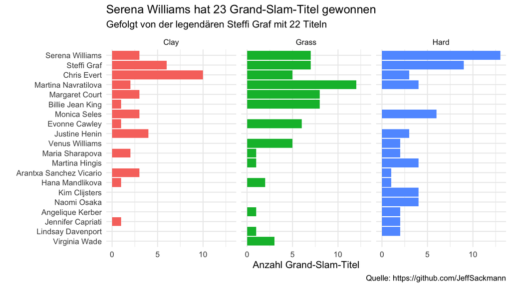

```r
total_wins_surface %>%
  filter(winner_name %in% top20) %>%
  ggplot(mapping = aes(x = total_wins,
                         y = winner_name,
                         fill = surface)) +
  geom_col() +
  labs(
    title = "Serena Williams hat 23 Grand-Slam-Titel gewonnen",
    subtitle =  "Gefolgt von der legendären Steffi Graf mit 22 Titeln",
    x = "Anzahl Grand-Slam-Titel",
    y = "",
    caption = "Quelle: https://github.com/JeffSackmann"
  ) +
  theme_minimal() +
  facet_wrap(vars(surface)) +
  theme(legend.position = "none") # die Legende entfernen
```

# 9 Grafiken exportieren

Wenn Sie mit Ihren Grafiken zufrieden sind, ist es Zeit, sie zu exportieren. Am einfachsten geht das mit `ggsave()`, das standardmässig die zuletzt angezeigte Grafik speichert. Sie müssen also nur den gewünschten Dateinamen als Argument angeben:

```r
ggsave("wta_wins_by_surface.png")
```

Standardmässig übernimmt das Bild die Grösse des aktuellen Grafikfensters (in RStudio der Bereich *Plots*) und ändert sich daher von Computer zu Computer. Um die Grösse festzulegen, verwenden Sie die Argumente `width` und `height`, standardmässig in Zoll:

```r
ggsave("wta_wins_by_surface_7x5.png", width = 7, height = 5)
```

# 10 Weitere Ressourcen

- [Das Buch zu `{ggplot2}`](https://ggplot2-book.org)
- [Spickzettel zu `{ggplot2}`](https://ggplot2.tidyverse.org)
- [Erweiterungen von `{ggplot2}`](https://exts.ggplot2.tidyverse.org)
- [R for data science](https://r4ds.had.co.nz)
- [Lösungen zu den Übungen von R for data science](https://jrnold.github.io/r4ds-exercise-solutions/)

# Zeit für eine Übung!

**WichtigAn die Arbeit!**

Öffnen Sie das Übungs-Notebook `_exercises/exercise-notebook.qmd` und lösen Sie **Übung 6**. Bis gleich!